# Notas Proyecto Integrador

Author

Matías Roqueta

$$\DeclareMathOperator*{\argmax}{argmax}
\DeclareMathOperator*{\argmin}{argmin}$$

## Transmisión OFDM en el estándar IEEE 802.11a

- PSDU: PHY Service Data Unit
- PPDU: PHY Protocol Data Unit

### TXVECTOR

El TXVECTOR es una serie de parámetros provistos por la capa MAC a la capa PHY para transmitir un PSDU. Mínimamente contiene los parámetros **DATARATE** Y **LENGTH**. En particular para OFDM contiene

| Parámetro | Valores | Descripción |
| --- | --- | --- |
| LENGTH | 1 - 4095 | El número de octetos que la capa MAC necesita transmitir |
| DATARATE | Distintas tasas según el espacio entre canales (20, 10 o 5 MHz) | La tasa de bits a la que se transmitirá la PSDU |
| SERVICE | Null | Siempre es Null |
| TXPWR_LEVEL_INDEX | 1-8 | Cual de los posibles TxPowerLevel definidos en la MIB serán usados en la transmisión |
| TIME_OF_DEPARTURE_REQUESTED | False o True | Determina si la capa MAC solicita tiempo de primer transmisión a la capa PHY |
| CH_BANDWIDTH_IN_NON_HT | Opcional: CBW20, CBW40, CBW80, CBW160, O CBW80+80 | Si está presente, modifica los primeros 7 bits de la secuencia de *scrambling* |
| DYN_BANDWIDTH_IN_NON_HT | Opcional: Static o Dynamic | Si es presente, modifica los primeros 7 bits de la secuencia de *scrambling* |

Transmitir una trama implica tomar una PSDU y codificarla en una PPDU que se transmite por el canal inalámbrico.

[figure not shown]

Los primeros 24 bits corresponden un símbolo OFDM, llamado SIGNAL. Se transmite:

- PHY Preamble: 12 símbolos OFDM
- SIGNAL: 1 símbolo OFDM
- DATA: N símbolos OFDM

[figure not shown]

PHY Preamble en el estándar 802.11a

### Parámetros Temporales

| Parámetros | Significado | Valor a 20 MHz | Nota |
| --- | --- | --- | --- |
| $\Delta_F$ | Espacio entre subportadoras | 0.3125 MHz | $\dfrac{20\;\mathrm{MHz}}{64}$ |
| $T_{FFT}$ | Período de FFT/IFFT | 3.2 $\micro$s | $\dfrac{1}{\Delta_F}$ |
| $T_{PREAMBLE}$ | Duración del PHY Preamble | 16 $\micro$s | $T_{SHORT}+T_{LONG}$ |
| $T_{SIGNAL}$ | Duración del símbolo SIGNAL | 4 $\micro$s | $T_{GI}+T_{FFT}$ |
| $T_{GI}$ | Duración del guard interval | 0.8 $\micro$s | $\dfrac{T_{FFT}}{4}$ |
| $T_{GI2}$ | Guard interval de la secuencia de entrenamiento | 1.6 $\micro$s | $\dfrac{T_{FFT}}{2}$ |
| $T_{SYM}$ | Intervalo de símbolo | 4 $\micro$s | $T_{GI}+T_{FFT}$ |
| $T_{SHORT}$ | Duración de la *short training sequence* | 8 $\micro$s | $10 \times \dfrac{T_{FFT}}{4}$ |
| $T_{LONG}$ | Duración de la *long training sequence* | 8 $\micro$s | $T_{GI2}+2\times T_{FFT}$ |

La función $w_T(t)$ es la función ventana temporal, definida por:

$$w_T(t) = \left\{
\begin{aligned}
\;&\sin^2\left[\tfrac{\pi}{2} \left(0.5 + \tfrac{t}{T_{TR}}\right)\right] \qquad &-\tfrac{T_{TR}}{2} < &t < \tfrac{T_{TR}}{2} \\
\;&1 \qquad & \tfrac{T_{TR}}{2} \le &t < T-\tfrac{T_{TR}}{2} \\
\;&\sin^2\left[\tfrac{\pi}{2} \left(0.5 - \tfrac{t-T}{T_{TR}}\right)\right] \qquad & T-\tfrac{T_{TR}}{2} \le &t < T+\tfrac{T_{TR}}{2} \\
\end{aligned}
\right.$$
En donde $T_{TR}$ del orden de los 100 ns es el tiempo de transición, la función $w_T(t)$ es efectivamente un pulso de duración $T$ con transición suave.

De ahora en más se trabaja con los valores correspondientes a 20 MHz

### Implementación IFFT

Una forma típica de realizar la IFFT consiste en una conversión de índices, haciendo una IFFT de 64 puntos de la señal $\bar x [m]$ con $m \in [0, 63]$ construida a partir de la señal $x[n]$ con $n \in [-26, 26]$ según:

$$\bar x [m] = \left\{
\begin{aligned}
&x[m] \qquad &m \in \left[1\phantom{1}, 26\right]\\
&x[m-64] \qquad &m \in \left[38, 63\right]\\
& 0 & \text{otherwise}
\end{aligned}
\right.$$

No está explícito en el manual, pero asumiría que si el FFT también es de 64 puntos y está bien sincronizado, las subportadoras se recuperarían de la señal temporal con una transformación de índices inversa.
$$x [n] = \left\{
\begin{aligned}
&\bar x[n+64] \qquad &n \in \left[-26, -1\right]\\
&\bar x[n] \qquad &n \in \left[\phantom{-}1, \phantom{-}26\right]\\
\end{aligned}
\right.$$

Sin embargo esto es MUY básico, sería un estimador que pierde información, y seguramente exista un método más inteligente.

[figure not shown]

Transformación frecuencia $\rightarrow$ tiempo

[figure not shown]

Transformación tiempo $\rightarrow$ frecuencia

### PHY Preamble

El PHY Preamble se utiliza para motivos de sincronismo, consiste en:

- 10 iteraciones de una *short training symbol*
- Un *guard interval*
- 2 iteraciones de una *long training symbol*

[figure not shown]

PHY Preamble en el estándar 802.11a, $t_i$ denota un *short training symbol* y $T_i$ un *long training symbol*.

La duración del instante temporal en la figura depende del espaciamiento entre canales.

- 20 MHz $\rightarrow$ 0.8 $\micro$s
- 10 MHz $\rightarrow$ 1.6 $\micro$s (half-clocked)
- 5 MHz $\rightarrow$ 3.2 $\micro$s (quarter-clocked)

#### Short Training Symbol

El *short training symbol* consiste en 12 subportadoras moduladas por los elementos de la secuencia $S$ del siguiente aspecto.
$$S_{-26,26} = \sqrt{\frac{13}{6}}\begin{bmatrix} 0 & 0 & 1+j & 0 & 0 & 0 & –1–j & 0 & 0 & \cdots \end{bmatrix}$$

Solo los índices múltiplos de 4 tienen señal (que puede ser “$j+1$” o “$-j-1$”), el factor multiplicativo normaliza la potencia media del símbolo OFDM, ya que este usa 12 de las 52 subportadoras: -24, -20, -16, -12, -8, -4, 4, 8, 12, 16, 20, 24.

La señal se construye a partir de

$$r_{SHORT}(t) = w_{TSHORT}(t) \sum_{k=-N_{ST}/2}^{N_{ST}/2}S_ke^{j2\pi k \Delta_F t}$$

O bien utilizando el módulo IFFT definido anteriormente, de esta forma la IFFT de una secuencia $S$ resulta en 4 períodos del *short training symbol*, por lo que la secuencia es $T_{FFT}/4$-periódica.

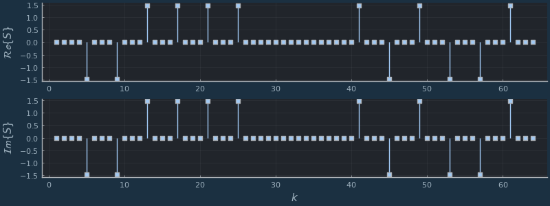

Descripción en frecuencia de la secuencia $S$ = 4 períodos del *short training symbol*

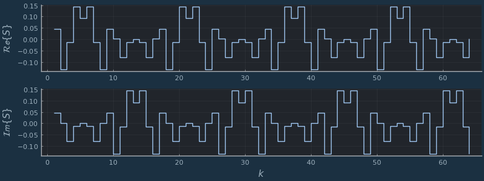

IFFT de la secuencia $S$ = 4 períodos del *short training symbol*

La secuencia de 10 *short training symbols* se concatena con una duración total de $T_{SHORT} = 10*T_{FFT}/4$

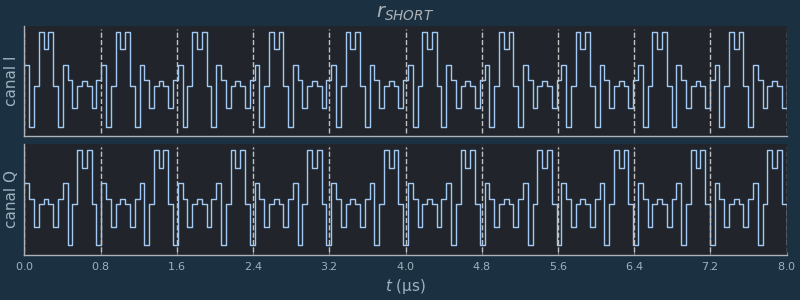

*short training sequence* en el dominio temporal

#### Long Training Symbol

El *long training symbol* consiste en 53 subportadoras (las 52 disponibles más el valor 0 en continua), moduladas por los elementos de la secuencia $L$ del siguiente aspecto:

$$L_{-26,26} = \begin{bmatrix} 1 & 1 & –1 & –1 & 1 & 1 & –1 & 1 & \cdots \end{bmatrix}$$

La señal se construye a partir de
$$r_{LONG}(t) = w_{TLONG}(t) \sum_{k=-N_{ST}/2}^{N_{ST}/2}L_ke^{j2\pi k \Delta_F (t-T_{GI2})}$$

O bien utilizando el módulo IFFT, de esta forma la IFFT de una secuencia $L$ retorna un período del *long training symbol*. Esta secuencia es $T_{FFT}$-periódica.

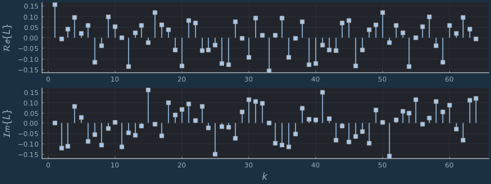

IFFT de la secuencia $L$ = 1 período del *long training symbol*

Se concatena el intervalo de guarda a dos períodos de la secuencia para obtener la *long training sequence* de duración $T_{LONG} = T_{GI2}+2\times T_{FFT}$

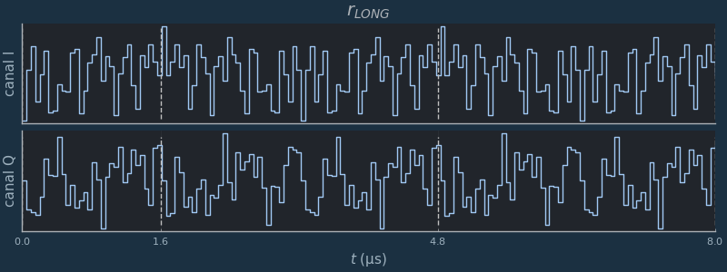

*long training sequence* en el dominio temporal

Finalmente las señales se concatenan para formar el PHY preamble

$$r_{PREAMBLE}(t) = r_{SHORT}(t)+r_{LONG}(t-T_{SHORT})$$

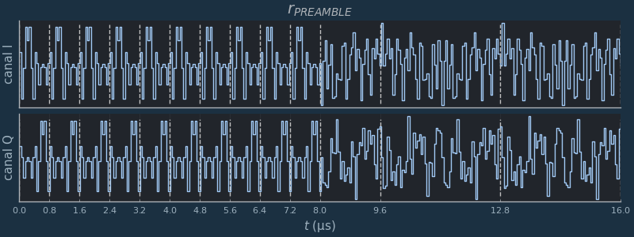

PHY Preamble en el dominio temporal

### PHY Header

Todo se construye a partir del TXVECTOR

- RATE, LENGTH: Obtenidos del TXVECTOR, se le agrega un bit de paridad par y un TAIL de 000000. Son codificados por un código convolucional a tasa 1/2, y asigados un único símbolo ODFM llamado SIGNAL que es transmitido con codificación BPSK.
- A partir de RATE del TXVECTOR se calcula
  - $R$: la tasa de codificación
  - $N_{DBPS}$: el número de bits *de datos* por símbolo OFDM
  - $N_{CBPS}$: el número de bits *codificados* por símbolo OFDM
  - $N_{BPSC}$: el número de bits por sub-portadora OFDM
- El PSDU se concatena a SERVICE de TXVECTOR. Se extiende con bits 0 (mínimo 6) hasta completar N símbolos OFDM. Esto es la secuencia de símbolos DATA.
- En función de si CH_BANDWIDTH_IN_NON_HT está o no presente en TXVECTOR, el *scrambler* se inicializa con una semilla pseudoaleatoria o usando este campo.
- Se aplica XOR de la secuencia de *scrambling* con los bits de DATA. Los 6 últimos bits luego se remplazan con 0. Estos últimos bits retornarán el codificador convolucional al estado inicial.
- La secuencia DATA se codifica con un código convolucional a tasa $R=1/2$, y luego se perfora para alcanzar la tasa definida en el parámetro RATE de TXVECTOR.
- La secuencia codificada se divide en tramas de $N_{CBPS}$ bits. Cada grupo se convierte en un símbolo según la tabla de modulación.
- El número total de subportadoras es 52, indexadas de -26 a 26. 48 de ellas transmiten datos y 4 subportadoras se insertan a modo de piloto en índices -21, -7, 7, y 21.
- A cada grupo de 52 subportadoras se aplica la IFFT, se adjunta el prefijo cíclico, y se usa una ventana temporal para truncar la forma resultante al largo de un símbolo ODFM.
- Los símbolos OFDM se concatenan a el símbolo SIGNAL, uno atrás del otro.
- La señal en banda base se eleva a RF con frecuencia central del canal de operación y se transmite.

### Parámetros dependientes de la modulación

Número de bits por subportadora, Número de bits codificados por símbolo ODFM, y número de bits de datos por símbolo en función de la modulación y la tasa de código

| Modulación | Tasa código $R$ | $N_{BPSC}$ | $N_{CBPS}$ | $N_{DBPS}$ |
| --- | --- | --- | --- | --- |
| BPSK | 1/2 | 1 | 48 | 24 |
| BPSK | 3/4 | 1 | 48 | 36 |
| QPSK | 1/2 | 2 | 96 | 48 |
| QPSK | 3/4 | 2 | 96 | 72 |
| 16-QAM | 1/2 | 4 | 192 | 96 |
| 16-QAM | 3/4 | 4 | 192 | 144 |
| 64-QAM | 2/3 | 6 | 288 | 192 |
| 64-QAM | 3/4 | 6 | 288 | 216 |

### SIGNAL y DATA

[figure not shown]

Estructura de un canal OFDM

### SIGNAL

El símbolo SIGNAL es transmitido inmediatamente después del PHY Preamble siempre con modulación BPSK y tasa de código 1/2

[figure not shown]

Símbolo SIGNAL en el estándar 802.11a.

#### RATE

Los bits [0:3] se asignan según la tasa de transmisión. No pueden tomar cualquier valor, sino alguno de los presentes en la siguiente tabla

Tasa de bits para 20 MHz entre canales. Es 1/2 de la registrada con 10 MHz entre canales, y 1/4 de la registrada con 5 MHz entre canales

| RATE | Tasa de bits con 20 MHz entre canales |
| --- | --- |
| 1101 | 6 MHz/s |
| 1111 | 9 MHz/s |
| 0101 | 12 MHz/s |
| 0111 | 18 MHz/s |
| 1001 | 24 MHz/s |
| 1011 | 36 MHz/s |
| 0001 | 48 MHz/s |
| 0011 | 54 MHz/s |

#### LENGTH

Los bits [5:16] un número en formato *unsigned integer* de 12 bits que indica el número de octetos que se transmitirán. Se transmite empezando por el bit menos significativo (LSB), que es el bit 5. Este campo es codificado con código convolucional.

#### RES, PAR, y SIGNAL TAIL

- RES: bit 4 está reservado para uso futuro, siempre vale 0.
- PAR: bit 17 es un bit de paridad par.
- TAIL: bits [18:23] son la SIGNAL TAIL, y siempre están en 0.

### DATA

El campo DATA contiene, en orden, el campo SERVICE, la PSDU, bits TAIL, y si es necesario bits PAD. Los bits son *scrambled*.

#### SERVICE

Es un campo de 16 bits con el siguiente formato

[figure not shown]

Campo SERVICE en el estándar 802.11a.

- Los bits [0:6] son puestos en 0, sincronizan el *descrambler* en el receptor
- Los bits [7:15] están reservados para uso futuro, son puestos en 0 en transmisión e ignorados en recepción.

#### PPDU TAIL

6 bits 0 al final de la PSDU, necesarios para retornar el codificador convolucional al estado 0.

#### PAD

El número de bits en DATA necesita ser un múltiplo de $N_{CBPS}$, para conseguirlo el mensaje es extendido hasta ser un múltiplo de $N_{DBPS}$. Se relaciona con el número de símbolos OFDM $N_{SYM}$, el número de bits DATA $N_{DATA}$ y el largo de la PSDU LENGTH de la siguiente forma

$$\begin{aligned}
&N_{SYM} = \left\lceil \dfrac{16+8\times \mathrm{LENGTH} +6}{N_{DBPS}}\right\rceil\\[1em]
&N_{DATA} = N_{SYM}\times N_{DBPS}\\[1em]
&N_{PAD} = N_{DATA} - (16+8\times\mathrm{LENGTH} +6)
\end{aligned}$$

Los bits PAD son puestos en 0 y *scrambled* con el resto de los bits en DATA.

### Scrambler

El campo DATA es *scrambled* con un *scrambler* sincrónico de largo 127. Usa el polinomio generador

$$S(x) = x^7+x^4+1$$

Y visto como una máquina de estados donde $\mathbf{x} = \begin{bmatrix} x_7 & \cdots & x_2\end{bmatrix}$ es un *linear feedback shift register* se puede interpretar así:

| Entrada | Estado Actual | Salida | Estado Siguiente |
| --- | --- | --- | --- |
| $y$ | $\begin{bmatrix} x_7 & x_6 & x_5 & x_4 & x_3 & x_2 & x_1 \end{bmatrix}$ | $y + x_7 + x_4$ | $\begin{bmatrix} x_6 & x_5 & x_4 & x_3 & x_2 & x_1 & x_7 + x_4 \end{bmatrix}$ |

El mismo scrambler es utilizado para transmitir que para recibir, lo cual implica que es su propia inversa (no sabría por que pero le creo al libro)

Si CH_BANDWITDH_IN_NON_HT está presente en TX_VECTOR el scrambler se inicializa según una tabla, de lo contrario, se inicializa con una secuencia pseudoaleatoria.

### Código Convolucional

Los bits en DATA son codificados con un código convolucional de tasas $R$ = 1/2, 2/3 o 3/4 correspondientes a RATE de TXVECTOR. Se codifican con los polinomios generadores $g_0 = 133_g$ y $g_1 = 171_g$. Ambas son de tasa 1/2 y las tasas mayores se consiguen con perforación de la secuencia codificada.

El receptor las decodifica con el algoritmo de Viterbi (a priori esto excede el alcance del proyecto, llegar hasta detectar, demodular, y desentrelazar una PPDU suena a un buen target)

### Entrelazado

Los bits codificados son entrelazados en bloques de tamaño $N_{CBPS}$. El entrelazador tiene dos etapas:

1. Bits adyacentes se transportan a subportadoras no-adyacentes
2. Bits adyacentes se transportan a bits más o menos significativos del símbolo en la constelación (correspondientes al canal $I$ y canal $Q$)

El índice de un bit se denominará de la siguiente forma

$$k \xrightarrow[\mathrm{etapa}]{\mathrm{1ra}} i \xrightarrow[\mathrm{etapa}]{\mathrm{2da}} j \qquad k,i,j \in \left[0, N_{CBPS}-1\right]$$

Las transformaciones de índice de cada etapa son definidas según las siguientes reglas:

$$\begin{aligned}
i &= \frac{N_{CPBS}}{16} \times (k \bmod 16) + \left\lfloor\frac{k}{16}\right\rfloor \\[1em]
j &= s \times \left\lfloor\frac{i}{s}\right\rfloor + \left[i+N_{CBPS} - \left\lfloor\frac{16 \times i}{N_{CBPS}}\right\rfloor\right] \bmod s
\end{aligned}$$

El desentrelazador en recepción también opera en dos etapas, con índices

$$j \xrightarrow[\mathrm{etapa}]{\mathrm{1ra}} i \xrightarrow[\mathrm{etapa}]{\mathrm{2da}} k \qquad j,i,k \in \left[0, N_{CBPS}-1\right]$$

Las transformaciones de índice son las inversas a las respectivas etapas de entrelazado

$$\begin{aligned}
i &= s \times \left\lfloor\frac{j}{s}\right\rfloor+\left[j+\left\lfloor\frac{16\times i}{N_{CBPS}}\right\rfloor\right] \bmod s\\[1em]
k &= 16 \times i - \left(N_{CBPS}-1\right) \times \left\lfloor\frac{16\times i}{N_{CBPS}}\right\rfloor
\end{aligned}$$

En donde $s$ es determinado por el número de bits por subportadora: $s = \max\left\{\frac{N_{BPSC}}{2}, 1\right\}$

Tabla de valores relevantes al entrelazado

| Modulación | $N_{CBPS}$ | $s$ |  |
| --- | --- | --- | --- |
| BPSK | 48 | 1 |  |
| QPSK | 96 | 1 |  |
| 16-QAM | 192 | 2 |  |
| 64-QAM | 288 | 3 |  |

Las ecuaciones en $\bmod N_{CBPS}$ son equivalentes a operaciones matriciales, y visualizarlas así resulta ilustrativo, por ejemplo:

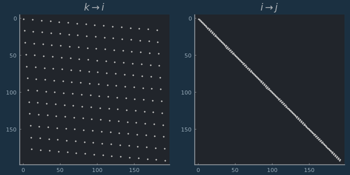

Matrices equivalentes de entrelazado para el caso de modulación 16-QAM. (sparse matrix de 1s)

Verifica que la etapa $k \leftrightarrow i$ es un entrelazado de “gran escala” que aplica a nivel símbolo OFDM, y la etapa $i \leftrightarrow j$ es un entrelazado de “pequeña escala” que aplica a nivel símbolo en la constelación.

### Modulación

Según el RATE se eligirá el esquema de modulación. Los bits entrelazados se dividen en grupos de $N_{BPSC}$ bits y se asignan un número complejo $I+jQ$ según la constelación correspondiente. Las constelaciónes están codificadas según código Gray.

En todos los casos (exceptuando BPSK que es de 1 bit), la codificación es tal que

- El canal $I$ es determinado únicamente por los $N_{BPSC}/2$ bits más significativos.
- El canal $Q$ es determinado únicamente por los $N_{BPSC}/2$ bits menos significativos.

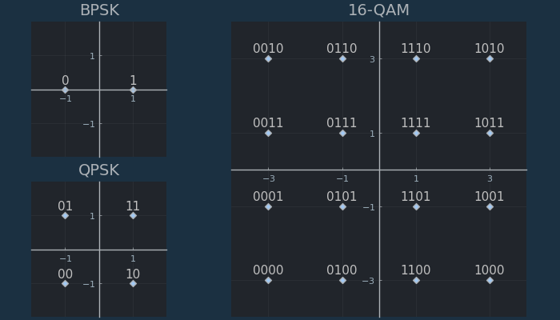

Codificación Gray en constelaciones BPSK, QPSK, 16-QAM. La constelación 64-QAM es similar con 6 bits codificados en una constelación de $8\times8$.

A cada constelación corresponde un factor de normalización $K_{MOD}$.

| Modulación | $K_{MOD}$ |
| --- | --- |
| BPSK | $1$ |
| QPSK | $\frac{1}{\sqrt{2}}$ |
| 16-QAM | $\frac{1}{\sqrt{10}}$ |
| 64-QAM | $\frac{1}{\sqrt{42}}$ |

Se genera un valor complejo por cada grupo de $N_{BPSC}$ bits: $d = K_{MOD}\times(I+jQ)$

### Modulación OFDM

#### Subportadoras de Datos

La secuencia de números complejos resultantes es dividida en grupos de $N_{SD} = 48$ números. En total hay $N_{SYM} \times N_{SD}$ números y se indexan

$$d_{k,m} \equiv d_{k+n \times N_{SD}} \qquad\qquad k \in [0, N_{SD}-1] \qquad n \in [0,N_{SYM}-1]$$

Los índices corresponden a la subportadora $k$ del símbolo OFDM número $n$. Se transforman a *offsets* de frecuencia omitiendo los índices de ondas piloto (-21, -7, 7, 21) y el nivel de contínua 0 con la función $M(k)$

$$M(k) = \left\{
\begin{aligned}
\,k-26 \qquad\qquad &k\in[0,4]\\
\,k-25 \qquad\qquad &k\in[5,17]\\
\,k-24 \qquad\qquad &k\in[18,23]\\
\,k-23 \qquad\qquad &k\in[24,29]\\
\,k-22 \qquad\qquad &k\in[30,42]\\
\,k-21 \qquad\qquad &k\in[43,47]\\
\end{aligned}
\right.$$

#### Ondas Piloto

Las subportadoras reservadas transmiten ondas pilotos para mantener la transmisión sincrónica. Transmiten una secuencia pseudoaleatoria con modulación BPSK.

La secuencia pseudoaleatoria usada para la modulación BPSK es generada por el *scrambler* definido anteriormente con estado inicial 1111111.

#### Símbolo OFDM

El símbolo OFDM $n$ de DATA es definido entonces

$$r_{DATA,n}(t) = w_{T_{SYM}}(t) \left[\sum_{k=0}^{N_{SD}-1} d_{k,n}e^{j2\pi M(k) \Delta_F (T-T_{GI})} + \sum_{k=-\frac{N_{ST}}{2}}^{\frac{N_{ST}}{2}} P_k e^{j2\pi k \Delta_F(t-T_{GI})}\right]$$

En donde $P_{-26,26}$ selecciona los índices asignados a ondas piloto

$$P_k = \left\{
\begin{aligned}
\phantom{-}1 \qquad\qquad &k\in\{\pm 7, -21\}\\
-1 \qquad\qquad &k = 21\\
\phantom{-}0 \qquad\qquad &k\notin\{\pm 7,\pm 21\}\\
\end{aligned}
\right.$$

No se por que está ahí ese -1

Hasta ahora

[figure not shown]

Estructura Transmisor

[figure not shown]

Estructura Receptor

El campo DATA transmitido es entonces la concacenación temporal de los $r_{DATA,n}$

$$r_{DATA} (t) = \sum_{n=0}^{N_{SYM}-1} r_{DATA, n}(t-nT_{SYM})$$

### Procedimiento

1. Se transmite la forma de onda predeterminada PHY Preamble para detección y sincronismo en el receptor
2. Se transmite el símbolo SIGNAL informando RATE y LENGTH. RATE define la modulación y tasa de código para la transmisión de DATA.
3. Se transmite DATA, la cantidad de símbolos transmitidos es definida por RATE y LENGTH.

[figure not shown]

Procedimiento de transmisión de una PSDU en el estándar IEEE 802.11

### Frecuencias de Operación

## Sincronización OFDM

Tipos de errores de sincronismo:

- Nivel Portadora
  - Carrier Frequency Offset $\Delta f$
  - Carrier Phase Offset $\phi (t)$
- Nivel Muestreo
  - Sampling Clock Offset $\delta$
- Nivel Símbolo
  - Symbol Timing Offset $T_d$

### Efectos de Error de Sincronismo

Consideramos un símbolo OFDM generado por la IFFT de $N$ números complejos sobre $N$ subportadoras.

- El espacio entre subportadoras es $1/T$ con $T$ la duración de $N$ muestras en el dominio del tiempo.
- El prefijo cíclico es de longitud $N_g$, por lo que el símbolo OFDM tiene $N+N_g$ muestras en total.
- La muestra $n$-ésima en el dominio temporal con $n \in [-N_g, N-1]$ del $i$-ésimo símbolo transmitido se expresa de la siguiente forma
  $$\begin{aligned}
  x_{i,n} &= x(i(N+N_g)T_s+N_gT_s+nT_s)\\[1em]
  x_{i,n} &= \frac{1}{N}\sum_{k=-\frac{N}{2}+1}^{\frac{N}{2}}X_{i,k}e^{j\frac{2\pi nk}{N}}
  \end{aligned}$$
- En donde $X_{i,k}$ es el $k$-ésimo valor en el dominio de la frecuencia del $i$-ésimo símbolo.

Suponemos que el canal es variante en el tiempo con desvanecimiento de $r$ caminos con la respuesta al impulso en tiempo $t$, pero cuasiestacionario en el tiempo de un símbolo OFDM:

$$h(t,\tau) = \sum_r h_r(t)\delta(\tau-\tau_r(t)) \approx \sum_r h_r \delta(\tau-\tau_r)$$

La señal recibida resulta de convolver la señal transmitida con la respuesta al impulso más ruido AWGN

$$z(\tau) = x(\tau)\ast h(\tau) + \nu(\tau) = \sum_r h_r x(\tau-\tau_r)+\nu(\tau)$$

Fourierizando

$$Z_k = X_k H_k + V_k \qquad \qquad H_k = \sum_r h_k e^{-j2\pi\frac{\tau_r k}{T_S N}}$$

### Offset Frecuencia de Portadora (CFO)

Un offset de frecuencia $\Delta f$ rota la señal recibida a frecuencia constante

$$z_{i,n} = z(t)e^{j2\pi\Delta ft}\big\rvert_{t=i(N+N_g)T_s+N_gT_s+nT_s}$$

Pasan cosas locas en el dominio de la frecuencia como resultado

### Offset de Muestreo (SCO)

Si la señal recibida se muestrea en intervalos $(1+\delta)T_S$ en lugar de $T_S$, entonces la $n$-ésima muestra del $i$-ésimo símbolo se convierte en

$$z_{i,n} = z(t)\big\rvert_{t=i(N+N_g)(1+\delta)T_S+N_g(1+\delta)T_S
n(1+\delta)T_S}$$

Esto también provoca cosas locas en el dominio de la frecuencia

### Offset de Symbol Timing

Considerando un retardo máximo en la respuesta al impulso del canal $\tau_{max}$, la ventana de DFT en receptor puede caer en varios escenarios.

### Detección de *Symbol Timing* Áspera

Usando la repetición del PHY preamble *short training sequence*. Teniendo muestras $z_m$ con longitud de intervalo de de repetiión $R$ y espaciamiento entre intervalos adyacentes $L$.

Existen varias técnicas y mirándolas eligiría el criterio MMSE. Estima el con criterio de mínimo error cuadrático medio, asumiendo que las señales recibidas son independientes exceptuando las réplicas.

$$\begin{aligned}
\Phi_{MMSE}(m)&= \sum_{r=0}^{R-1}\left[|z_{m-r}|^2+|z_{m-r-L}|^2\right] - 2\left\lvert\sum_{r=0}^{R-1}z_{m-r}z_{m-r-L}^\star\right\rvert \\[1em]
\hat{m}_{MMSE} &= \argmin_m \left[\Phi_{MMSE}(m)\right]
\end{aligned}$$

Es equivalente al método de máxima verosimilitud asumiendo SNR infinita.

### Estimación de *Carrier Frequency Offset*

Existen mil métodos y a partir de una lectura breve eligiría el BLUE (Best Linear Unbiased Estimator).

Si el preámbulo tiene $U > 2$ repeticiones idénticas, con $R$ muestras en un período tal que $N=RU$ muestras existen, se parte de calcular varias autocorelaciones a partir de $uR$ muestras.

$$\Phi_{BLUE}(u) = \frac{1}{N-uR} \sum_{m=uR}^{N-1} z_mz^\ast_{m-uR} \qquad\qquad u\in[0, K]$$

Se mide la diferencia de fase entre todo par de autocorrelaciones con diferencia en tiempo $R$.

$$\phi(u) = \left[\angle\{\Phi_{BLUE}(u)\}-\angle\{\Phi_{BLUE}(u-1)\}\right]_{2\pi} \qquad\qquad u\in[1,K]$$

El estimador BLUE consiste en un promedio ponderado de estas diferencias de fase.

$$\frac{\hat{\Delta f}}{f_S} = \frac{U}{2\pi}\sum_{u=1}^K w_u\phi(u) \qquad \text{con} \qquad w_u = 3 \frac{(U-u)(U-u+1)- K(U-K)}{K(4K^2-6UK+3U^2-1)}$$

El valor óptimo de $K$ para adquirir varianza mínima del estimador es $K=U/2$

## Modelo Canal OFDM

Para transmitir datos en un canal OFDM se hace en bloques de $N_T$ símbolos, los datos a transmitir se necesita subdividir en tramas de longitud $N_C$

- $N_C$: Longitud en símbolos de datos de una trama
- $L$: Longitud en símbolos de la ISI
- $N_T$: Longitud de símbolos transmitidos por el canal. Para no tener ISI se necesita $N_T = N_C+L-1$

La transmisión de datos en un canal OFDM sigue el siguiente método:

- A un vector de datos $\mathbf{\tilde x}$ de longitud $N_C$ se le aplica la transformada inversa de Fourier, obteniendo
  $$\mathbf x = \mathcal F^{-1}[\mathbf{\tilde x}]$$
- A $\mathbf x$ se le agregan $L-1$ símbolos de prefijo cíclico, obteniendo el vector $\mathbf{\bar x}$ de longitud $N_T$.
  $$\mathbf{\bar x} = \begin{bmatrix}x_{N_C-L+1} & \cdots & x_{N_C-1} & x_0 & \cdots & x_{N_C-1} \end{bmatrix}$$
- El vector $\mathbf{\bar x}$ se transmite por el canal $\mathbf h$, obteniendo
  $$\mathbf{\bar y} = \mathbf h \ast \mathbf{\bar x} + \mathbf w$$
- Se ignora el prefijo de $\mathbf{\bar y}$, quedándose únicamente con los últimos $N_C$ símbolos
  $$\mathbf y = \begin{bmatrix}\bar y_L & \cdots & \bar y_{N_C+L-1}\end{bmatrix}$$
- A $\mathbf y$ se le aplica la transformada de Fourier, obteniendo el vector final recibido
  $$\mathbf{\tilde y} = \mathcal F[\mathbf{y}]$$

[figure not shown]

Estructura de un canal OFDM

La relación final entre el vector transmitido $\mathbf{\tilde x}$, el vector recibido $\mathbf{\tilde y}$, y el canal $\mathbf h$ es

$$\mathbf{\tilde y} = \mathbf{\tilde h}^\star \mathbf{\tilde x} + \mathbf{\tilde w}$$

En donde (asumo, porque el Tse no es super explícito al respecto) que $\mathbf{\tilde h} = \mathcal F[\mathbf h]$. Efectivamente se usa la identidad

$$\mathbf y = \mathbf h \ast \mathbf x + \mathbf w \longleftrightarrow \mathbf{\tilde y} = \mathbf{\tilde h}^\star \mathbf{\tilde x} + \mathbf{\tilde w}$$

### Prefijos cíclicos

Esto no está en el Tse, pero agregar o quitar prefijos cíclicos podría ser interpretado como operaciones matriciales

Ej con $N_C=5$ y $L=4$ entonces $N_T=8$

- Agregar prefijo:
  $$\begin{bmatrix}
  x_2 \\ x_3 \\ x_4 \\ x_0 \\ x_1 \\ x_2 \\ x_3 \\ x_4
  \end{bmatrix} =
  \begin{bmatrix}
  0 & 0 & 1 & 0 & 0 \\
  0 & 0 & 0 & 1 & 0 \\
  0 & 0 & 0 & 0 & 1 \\
  1 & 0 & 0 & 0 & 0 \\
  0 & 1 & 0 & 0 & 0 \\
  0 & 0 & 1 & 0 & 0 \\
  0 & 0 & 0 & 1 & 0 \\
  0 & 0 & 0 & 0 & 1 \\
  \end{bmatrix}
  \begin{bmatrix}
  x_0 \\ x_1 \\ x_2 \\ x_3 \\ x_4
  \end{bmatrix}$$
- Quitar prefijo:
  $$\begin{bmatrix}
  y_3 \\ y_4 \\ y_5 \\ y_6 \\ y_7
  \end{bmatrix} =
  \begin{bmatrix}
  0 & 0 & 0 & 1 & 0 & 0 & 0 & 0 \\
  0 & 0 & 0 & 0 & 1 & 0 & 0 & 0 \\
  0 & 0 & 0 & 0 & 0 & 1 & 0 & 0 \\
  0 & 0 & 0 & 0 & 0 & 0 & 1 & 0 \\
  0 & 0 & 0 & 0 & 0 & 0 & 0 & 1 \\
  \end{bmatrix}
  \begin{bmatrix}
  y_0 \\ y_1 \\ y_2 \\ y_3 \\ y_4 \\ y_5 \\ y_6 \\ y_7
  \end{bmatrix}$$

Ya que los demás procedimientos, FFT, IFFT, convolución circular, eventualmente códigos de corrección de errores, eventualmente entrelazado (tampoco lo menciona el Tse), etc son operaciones matriciales, esta interpretación puede resultar útil